# PBMC: Computational Correction Cold Shock

Ramon Massoni-Badosa

10/21/2019

# 1 Introduction

The objective of this notebook is to create a cell-specific “cold-shock score” using the cold-shock transcriptomic signature. We will assess the potential of this score in predicting and correcting cold-shocked cells.

# 2 Pre-processing

## 2.1 Package loading

```r
library(scater)
library(scran)
library(Seurat)
library(ggpubr)
library(biomaRt)
library(org.Hs.eg.db)
library(AnnotationDbi)
library(GOplot)
library(GOstats)
library(kBET)
library(topGO)
library(ggrepel)
library(viridis)
library(DescTools)
library(pheatmap)
library(tidyverse)
```

## 2.2 Source script with functions

```r
source("bin/utils.R")
```

## 2.3 Load data

We dispose of a demultiplexed, filtered, normalized and annotated Seurat object that contains the transcriptome and metadata of >10,000 Peripheral Blood Mononuclear Cells (PBMC) from two donors (male/female) that were kept at varying times at RT (0h, 2h, 8h, 24h, 48h).

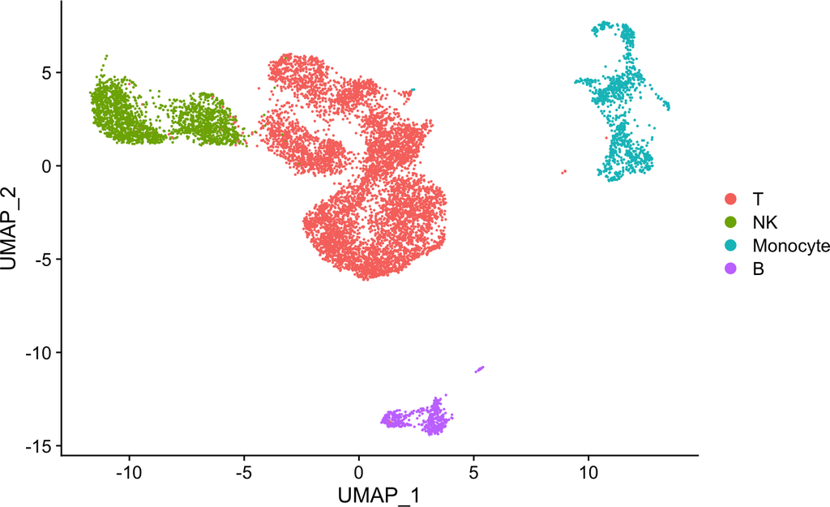

```r
pbmc <- readRDS("results/R_objects/10X_pbmc_Seurat_clustered.RDS")
pbmc <- subset(pbmc, subset = condition %in% c("0h", "2h", "8h", "24h_RT", "48h_RT"))
pbmc$time <- factor(pbmc$condition, levels = c("0h", "2h", "8h", "24h_RT", "48h_RT"))
levels(pbmc$time) <-  c("0h", "2h", "8h", "24h", "48h")
Idents(pbmc) <- "cell_type"
DimPlot(pbmc)
```

# 3 Cold-shock score

We will divide the PBMC dataset in training set (male) and test set (female). First, let us find the signature in the training set:

```r
pbmc$is_biased <- ifelse(pbmc$time %in% c("0h", "2h"), "unbiased", "biased")
pbmc_donor <- SplitObject(pbmc, split.by = "donor")
Idents(pbmc_donor$male) <- "is_biased"
dea <- FindMarkers(pbmc_donor$male, ident.1 = "biased")
cold_shock_signature <- rownames(dea)[1:150]
head(cold_shock_signature)
```

```
## [1] "TMSB10" "TMSB4X" "CD52"   "PFN1"   "ACTB"   "IL32"
```

With the signature, we can compute a cold-shock score for every cell in the test set:

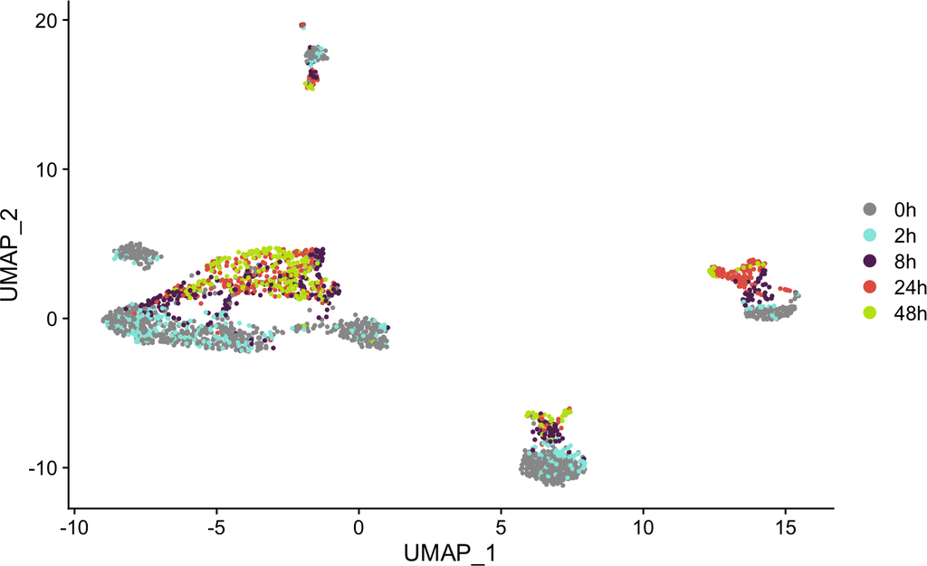

```r
pbmc_donor <- map(pbmc_donor, pre_process_seurat)
pbmc_donor <- map(pbmc_donor, RunTSNE, reduction = "pca", dims = 1:15)
Idents(pbmc_donor$female) <- "time"
palette <- c("#999999", "#92e8df", "#632c63", "#e4624e", "#c0e212")
original_umap <- DimPlot(
  pbmc_donor$female,
  reduction = "umap",
  cols = palette
)
original_umap
```

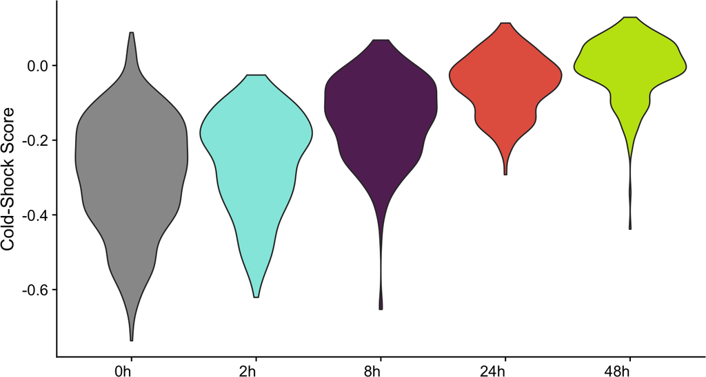

```r
original_tsne <- DimPlot(
  pbmc_donor$female,
  reduction = "tsne",
  cols = palette
)
pbmc_donor <- map(
  pbmc_donor,
  AddModuleScore,
  features = list(cold_shock_signature),
  name = "cold_shock_score"
)
pbmc_donor <- purrr::map(pbmc_donor, function(seurat) {
  seurat$cold_shock_score1 <- -1 * seurat$cold_shock_score1
  seurat
})

vln_cold_score <- VlnPlot(
  pbmc_donor$female,
  features = "cold_shock_score1",
  cols = c("#999999", "#92e8df", "#632c63", "#e4624e", "#c0e212"),
  group.by = "time",
  pt.size = 0
)
vln_cold_score <- vln_cold_score +
  labs(title = "", x = "", y = "Cold-Shock Score") +
  theme(axis.text.x = element_text(angle = 0)) +
  theme(legend.position = "none")
vln_cold_score
```

```r
# saveRDS(vln_cold_score, "results/R_objects/ggplots/violin_cold_shock_score.rds")
```

# 4 Predict biased cells

To predict cold-shocked cells, we will use a logistic regression, using cold-shock score as explanatory variable and the probability of being cold-shocked as the response variable. To learn more about logistic regression and how to apply it in R, I recomend the book [“Introduction to Statistical Learning”](https://faculty.marshall.usc.edu/gareth-james/ISL/ISLR%20Seventh%20Printing.pdf), by Gareth James and colleagues.

```r
# Fit logistic regression model
set.seed(123)
random_genes <- sample(rownames(pbmc), size = length(cold_shock_signature), replace = FALSE)
pbmc_donor <- map(pbmc_donor, AddModuleScore, features = list(random_genes), name = "random_score")
train_df <- data.frame(
  cold_shock_score = pbmc_donor$male$cold_shock_score1,
  random_score = pbmc_donor$male$random_score1,
  class = factor(ifelse(pbmc_donor$male$is_biased == "biased", 1, 0))
)
logistic_fit <- glm(class ~ cold_shock_score, train_df, family = "binomial")
summary(logistic_fit)
```

```
##
## Call:
## glm(formula = class ~ cold_shock_score, family = "binomial",
##     data = train_df)
##
## Deviance Residuals:
##     Min       1Q   Median       3Q      Max
## -2.6345  -0.6442  -0.0695   0.6246   4.0810
##
## Coefficients:
##                  Estimate Std. Error z value Pr(>|z|)
## (Intercept)       2.08841    0.05609   37.23   <2e-16 ***
## cold_shock_score 15.73336    0.36663   42.91   <2e-16 ***
## ---
## Signif. codes:  0 '***' 0.001 '**' 0.01 '*' 0.05 '.' 0.1 ' ' 1
##
## (Dispersion parameter for binomial family taken to be 1)
##
##     Null deviance: 10212  on 7377  degrees of freedom
## Residual deviance:  6143  on 7376  degrees of freedom
## AIC: 6147
##
## Number of Fisher Scoring iterations: 5
```

```r
logistic_random <- glm(class ~ random_score, train_df, family = "binomial")
summary(logistic_random)
```

```
##
## Call:
## glm(formula = class ~ random_score, family = "binomial", data = train_df)
##
## Deviance Residuals:
##    Min      1Q  Median      3Q     Max
## -1.161  -1.138  -1.130   1.217   1.236
##
## Coefficients:
##              Estimate Std. Error z value Pr(>|z|)
## (Intercept)  -0.09920    0.02649  -3.745 0.000181 ***
## random_score  0.49850    1.06608   0.468 0.640068
## ---
## Signif. codes:  0 '***' 0.001 '**' 0.01 '*' 0.05 '.' 0.1 ' ' 1
##
## (Dispersion parameter for binomial family taken to be 1)
##
##     Null deviance: 10212  on 7377  degrees of freedom
## Residual deviance: 10212  on 7376  degrees of freedom
## AIC: 10216
##
## Number of Fisher Scoring iterations: 3
```

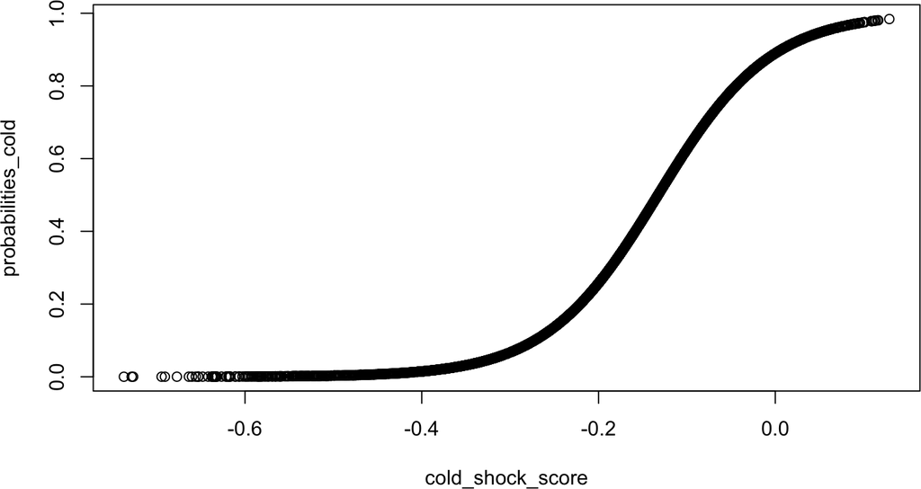

```r
# Predict probabilities on test set
test_df <- data.frame(
  cold_shock_score = pbmc_donor$female$cold_shock_score1,
  random_score = pbmc_donor$female$random_score1,
  class = factor(ifelse(pbmc_donor$female$is_biased == "biased", 1, 0))
)

test_df$probabilities_cold <- predict(logistic_fit, newdata = test_df, type = "response")
test_df$probabilities_random <- predict(logistic_random, newdata = test_df, type = "response")
plot(probabilities_cold ~ cold_shock_score, data = test_df)
```

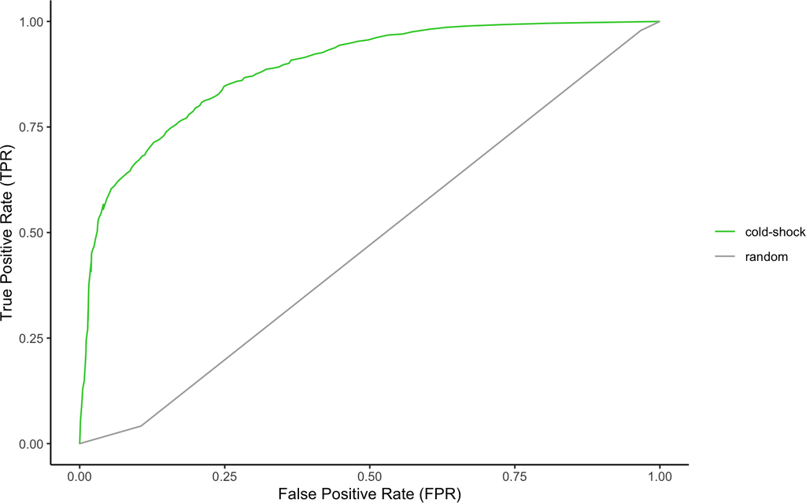

```r
# Plot ROC curve
thresholds <- seq(from = 0, to = 1, by = 0.01)
positives_ind <- which(test_df$class == 1)
negatives_ind <- which(test_df$class == 0)
accuracies_l <- map(c("probabilities_cold", "probabilities_random"), function(x) {
  l <- map(thresholds, function(thresh) {
    pred <- ifelse(test_df[[x]] > thresh, 1, 0)
    tpr <- mean(pred[positives_ind] == 1)
    fpr <- 1 - mean(pred[negatives_ind] == 0)
    list(tpr = tpr, fpr = fpr)
  })
  l
})
names(accuracies_l) <- c("cold_shock_score", "random_score")
accuracies_l <- map(accuracies_l, function(l) {
  tpr_dbl <- map_dbl(l, "tpr")
  fpr_dbl <- map_dbl(l, "fpr")
  roc_df <- data.frame(TPR = tpr_dbl, FPR = fpr_dbl)
  roc_df
})
accuracies_df <- bind_rows(accuracies_l, .id = "score")
roc_gg <- ggplot(accuracies_df, aes(FPR, TPR, color = score)) +
  geom_line() +
  labs(x = "False Positive Rate (FPR)", y = "True Positive Rate (TPR)", color = "") +
  scale_color_manual(values = c("limegreen", "darkgray"), labels = c("cold-shock", "random")) +
  theme_classic()
roc_gg
```

```r
auroc <- map_dbl(c("cold_shock_score", "random_score"), function(x) {
  df <- accuracies_df[accuracies_df$score == x, ]
  AUC(x = df$FPR, y = df$TPR, method = "spline")
})
names(auroc) <- c("cold_shock_score", "random_score")
auroc
```

```
## cold_shock_score     random_score
##        0.8878681        0.4637406
```

```r
# saveRDS(roc_gg, file = "results/R_objects/ggplots/roc_curve_pbmc.rds")
```

# 5 Regress Out

Now, let us regress the expression of each gene onto cold shock score. We will do this for each cell type separately to minimize [Simpson’s paradox](https://ds.czbiohub.org/blog/Regression-Hazards/). Then, we will keep the residuals as the variability not explained by time:

```r
seu <- pbmc_donor$female
Idents(seu) <- "cell_type"
cell_types <- c("T", "Monocyte", "NK", "B")
mat_l <- purrr::map(cell_types, function(type) {
  print(type)
  seurat <- subset(seu, idents = type)
  mat <- as.matrix(seurat[["RNA"]]@data[VariableFeatures(seurat), ])
  lm_l <- apply(mat, 1, function(x) lm(x ~ seurat$cold_shock_score1))
  names(lm_l) <- VariableFeatures(seurat)
  residuals_list <- purrr::map(lm_l, "residuals")
  residuals_mat <- Reduce(rbind, residuals_list)
  rownames(residuals_mat) <- names(lm_l)
  colnames(residuals_mat) <- colnames(seurat)
  mean_expr <- rowMeans(mat)
  residuals_mat <- residuals_mat + mean_expr
  residuals_mat_sc <- scale(residuals_mat, center = TRUE, scale = TRUE)
  residuals_mat_sc <- residuals_mat_sc[rownames(seurat[["RNA"]]@scale.data), ]
})
```

```
## [1] "T"
## [1] "Monocyte"
## [1] "NK"
## [1] "B"
```

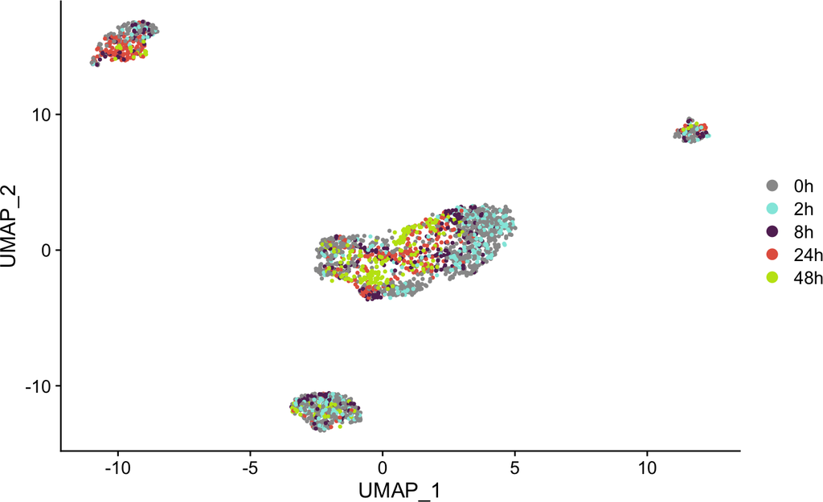

```r
names(mat_l) <- cell_types

# Join matrices and process
pbmc_female2 <- pbmc_donor$female
mat_all <- Reduce(cbind, mat_l)
mat_all <- mat_all[rownames(seu[["RNA"]]@scale.data), colnames(seu)]
pbmc_female2[["RNA"]]@scale.data <- mat_all
pbmc_female2 <- RunPCA(pbmc_female2)
pbmc_female2 <- RunUMAP(pbmc_female2, reduction = "pca", dims = 1:20)
pbmc_female2 <- RunTSNE(pbmc_female2, reduction = "pca", dims = 1:20)
Idents(pbmc_female2) <- "time"
umap_corrected <- DimPlot(pbmc_female2, reduction = "umap", cols = palette)
tsne_corrected <- DimPlot(pbmc_female2, reduction = "tsne", cols = palette)
umap_corrected
```

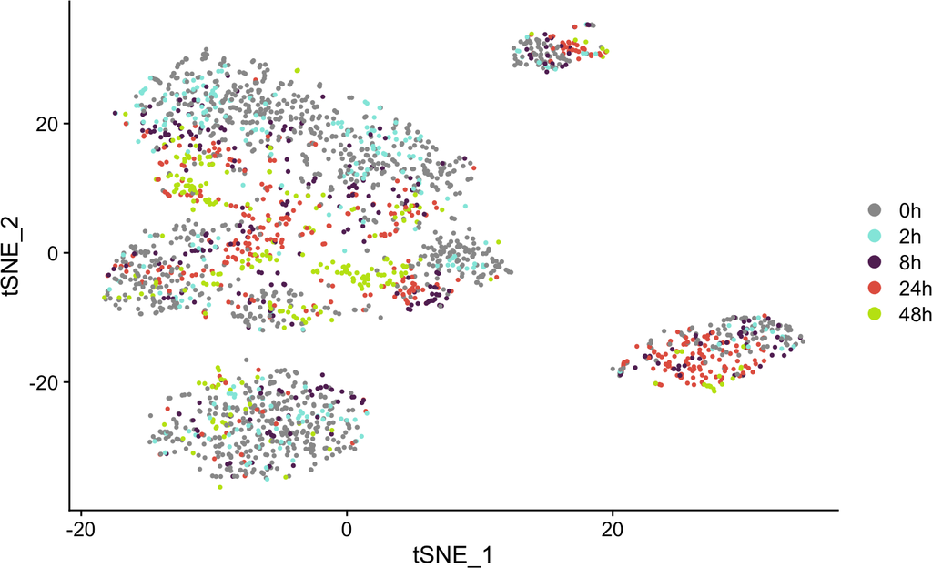

```r
tsne_corrected
```

```r
# ggarrange(plotlist = list(original_umap, umap_corrected), ncol = 2)
# saveRDS(
#   list(original = original_umap, corrected = umap_corrected),
#   "results/R_objects/ggplots/umaps_original_correction_pbmc.rds"
# )
# saveRDS(
#   list(original = original_tsne, corrected = tsne_corrected),
#   "results/R_objects/ggplots/tsnes_original_correction_pbmc.rds"
# )
```

# 6 kBET

To quantify the mixability between time-points, we will use the metric [kBET](https://www.nature.com/articles/s41592-018-0254-1). Intuitively, kBET compares the proportion of k-nearest neighbors that belong to each time-point with the global distribution. We say that a dataset is well-mixed if the local neighborhood approximates the global. The documentation of the package can be found [here](https://github.com/theislab/kBET).

```
## Initial neighbourhood size is set to 190.
## reducing dimensions with svd first...
## finding knns...done. Time:
##    user  system elapsed
##   0.087   0.001   0.094
## KNN input is a list, extracting nearest neighbour index.
```

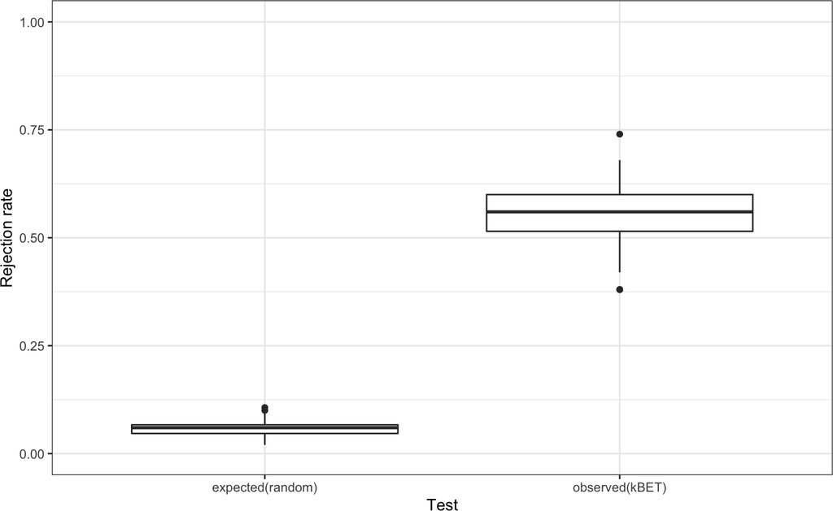

```
## Initial neighbourhood size is set to 197.
## reducing dimensions with svd first...
## finding knns...done. Time:
##    user  system elapsed
##   0.094   0.002   0.097
## KNN input is a list, extracting nearest neighbour index.
```

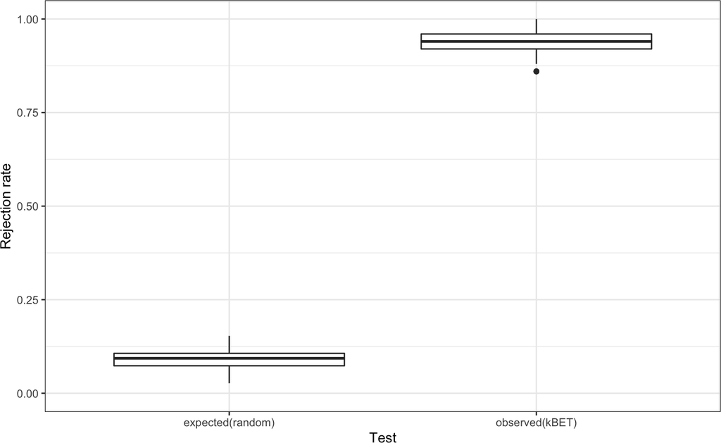

```
## Initial neighbourhood size is set to 208.
## reducing dimensions with svd first...
## finding knns...done. Time:
##    user  system elapsed
##   0.111   0.001   0.114
## KNN input is a list, extracting nearest neighbour index.
```

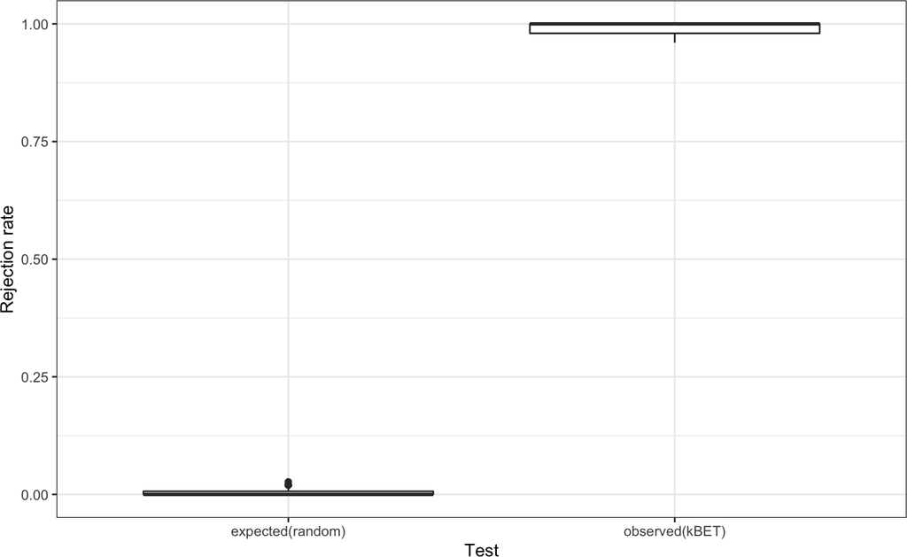

```
## Initial neighbourhood size is set to 191.
## reducing dimensions with svd first...
## finding knns...done. Time:
##    user  system elapsed
##   0.086   0.000   0.087
## KNN input is a list, extracting nearest neighbour index.
```

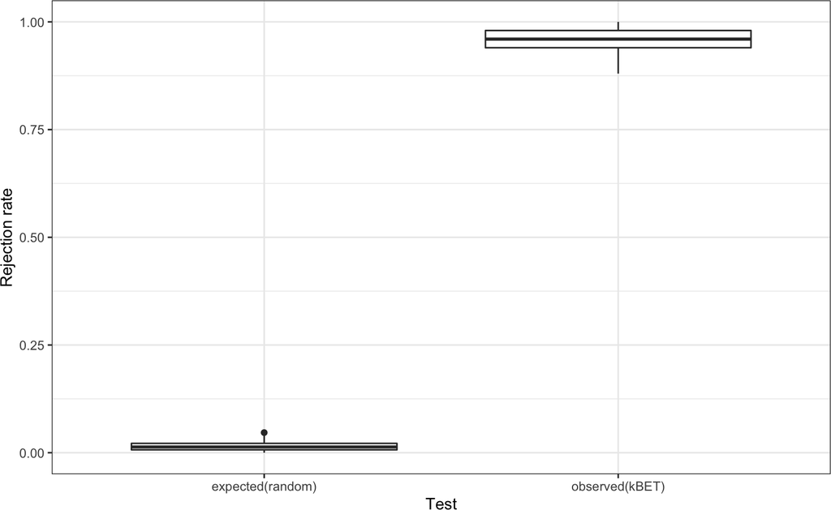

```
## Initial neighbourhood size is set to 190.
## reducing dimensions with svd first...
## finding knns...done. Time:
##    user  system elapsed
##   0.085   0.000   0.086
## KNN input is a list, extracting nearest neighbour index.
```

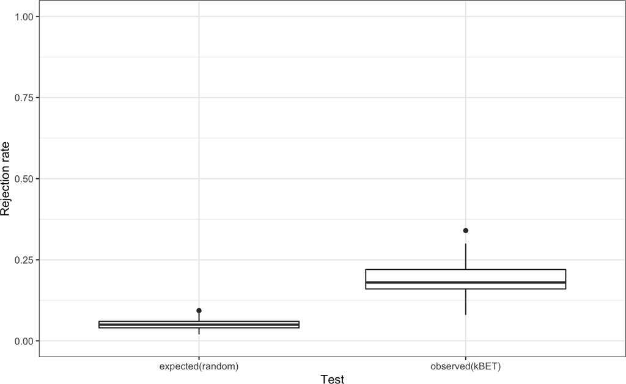

```
## Initial neighbourhood size is set to 197.
## reducing dimensions with svd first...
## finding knns...done. Time:
##    user  system elapsed
##   0.094   0.001   0.097
## KNN input is a list, extracting nearest neighbour index.
```

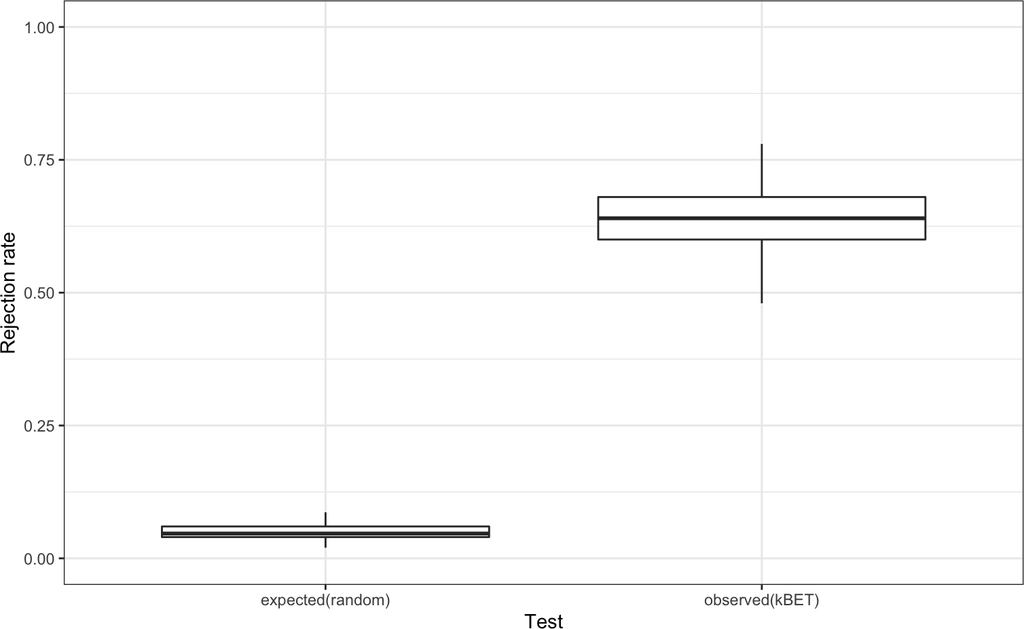

```
## Initial neighbourhood size is set to 208.
## reducing dimensions with svd first...
## finding knns...done. Time:
##    user  system elapsed
##   0.108   0.001   0.110
## KNN input is a list, extracting nearest neighbour index.
```

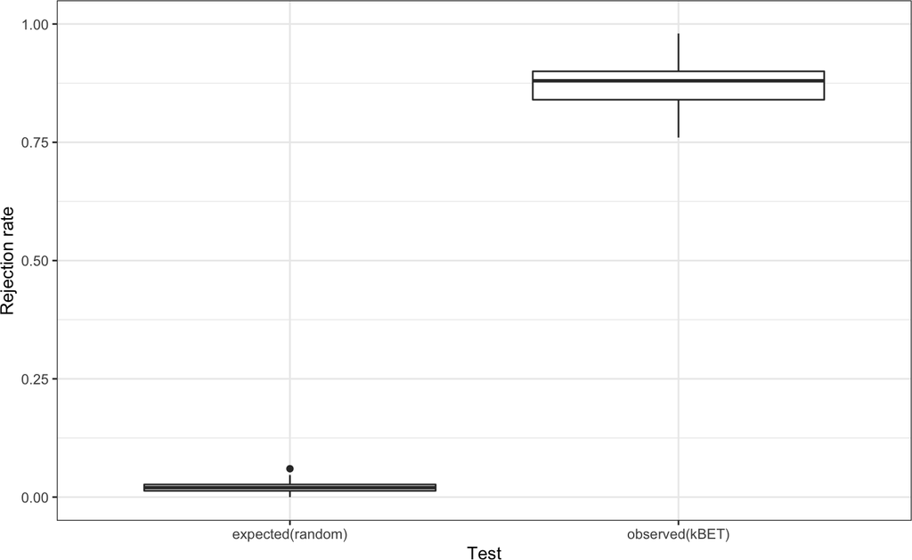

```
## Initial neighbourhood size is set to 191.
## reducing dimensions with svd first...
## finding knns...done. Time:
##    user  system elapsed
##   0.087   0.000   0.088
## KNN input is a list, extracting nearest neighbour index.
```

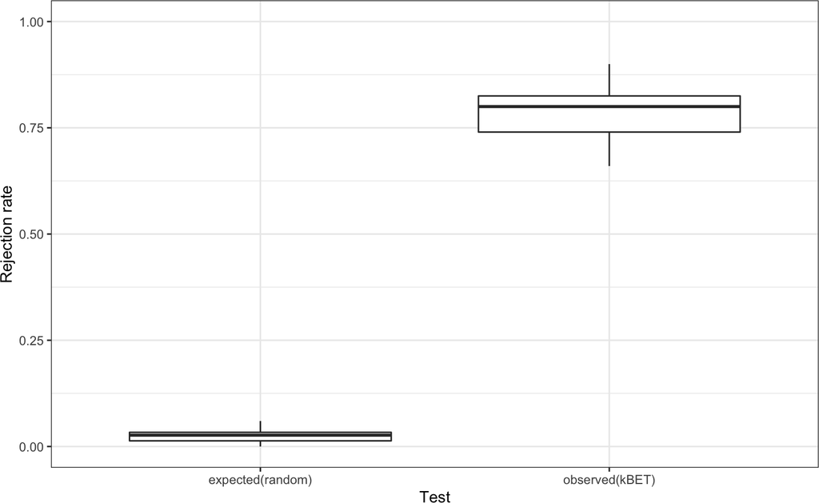

```r
# Calculate rejection rates
pbmc_female <- pbmc_donor$female
times <- c("2h", "8h", "24h", "48h")
acceptance_rates <- purrr::map(list(pbmc_female, pbmc_female2), function(seurat) {
  Idents(seurat) <- "time"
  acceptance_rate_dbl <- purrr::map_dbl(times, function(t) {
    seurat_sub <- subset(seurat, idents = c("0h", t))
    seurat_sub$is_biased <- ifelse(seurat_sub$time == "0h", FALSE, TRUE)
    mat <- as.matrix(seurat_sub@reductions$umap@cell.embeddings)
    batch <- seurat_sub$is_biased
    batch_estimate <- kBET(mat, batch = batch, verbose = TRUE, heuristic = FALSE, testSize = 50)
    batch_results <- batch_estimate$results
    batch_results <- batch_results %>%
      mutate(cell_type = seurat_sub$cell_type,
             time = seurat_sub$time) %>%
      filter(tested == 1) %>%
      summarise(acceptance_rate = mean(kBET.pvalue.test > 0.05) * 100)
    batch_results$acceptance_rate
  })
  data.frame(time = times, acceptance_rate = acceptance_rate_dbl)
})
```

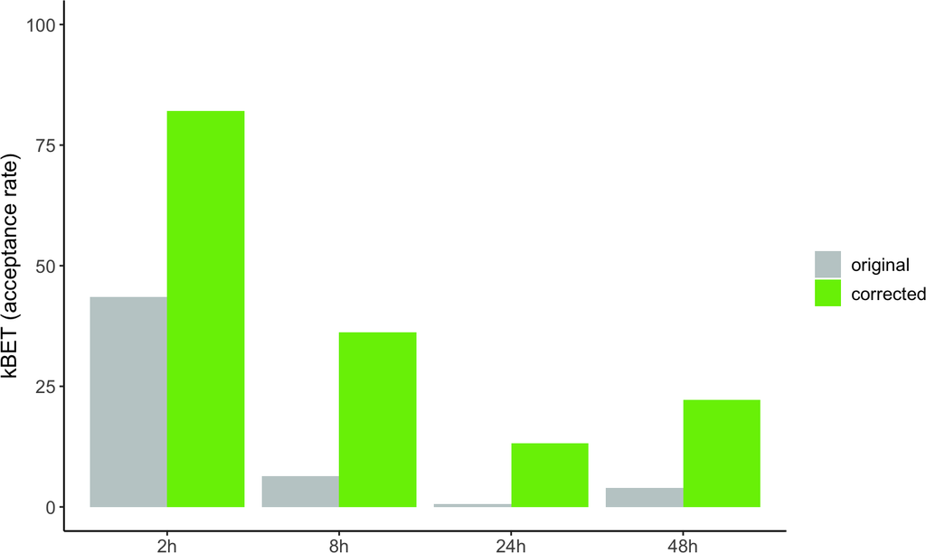

```r
names(acceptance_rates) <- c("original", "corrected")
acceptance_rates <- bind_rows(acceptance_rates, .id = "is_corrected")
acceptance_rates_gg <- acceptance_rates %>%
  mutate(time = factor(time, levels = c("0h", "2h", "8h", "24h", "48h")),
         is_corrected = factor(is_corrected, levels = c("original", "corrected"))) %>%
  ggplot(aes(time, acceptance_rate, fill = is_corrected)) +
    geom_col(position = "dodge") +
    scale_y_continuous(limits = c(0, 100)) +
    scale_fill_manual(values = c("azure3", "chartreuse2")) +
    labs(x = "", y = "kBET (acceptance rate)", fill = "") +
    theme_classic() +
    theme(axis.text = element_text(size = 11),
          axis.title.y = element_text(size = 13),
          legend.text = element_text(size = 11))
acceptance_rates_gg
```

```r
# saveRDS(acceptance_rates_gg, "results/R_objects/ggplots/barplot_acceptance_rate_correction_pbmc.rds")
```